# Zadania

Szymon Szrajer

13 05 2021

## Zadanie 1

**Testy “z wyboru”:**

test chi kwadrat

**Założenia teoretycznie dotyczące rozkładu wymagane dla wybranego testu:**

minimalna wielkość próby wynosząca 5 osobników, niezależność prób.

```r
data_test <- read.table(file = "Dane_Test1.txt",
                        sep = "\t",
                        header = T,
                        stringsAsFactors = T)
```

```r
summary(data_test)
```

```
##        Nr         Kolor        DP              DL
##  Min.   :  1.00   B:27   Min.   :14.29   Min.   :14.15
##  1st Qu.: 25.75   C:20   1st Qu.:19.86   1st Qu.:19.89
##  Median : 50.50   S:53   Median :22.56   Median :22.60
##  Mean   : 50.50          Mean   :22.51   Mean   :22.47
##  3rd Qu.: 75.25          3rd Qu.:24.59   3rd Qu.:24.76
##  Max.   :100.00          Max.   :30.26   Max.   :31.01
```

**Założenia teoretyczne:**  
Rozkład:  
Jest przynajmniej 5 osobników w próbie, z założeń zadania grupy są niezależne.

```r
chisq.test(x = table(data_test$Kolor), y = NULL, correct = FALSE,
          p = c(0.25,0.25,0.5))
```

```
##
##  Chi-squared test for given probabilities
##
## data:  table(data_test$Kolor)
## X-squared = 1.34, df = 2, p-value = 0.5117
```

**Wniosek:**

Wartość p-value wynosi 0,5117, jest to zatem wartość dużo wyższa niż próg 0,05 w rozważaniach statystycznych tym samym należy przyjąć hipotezę zerową, która w tym zadaniu to: **Frekwencja alleli nie różni się od oczekiwanej frekwencji alleli dla genu z kodominacją**

## Zadanie 2

**Statystyki opisowe:**

```r
data_test %>% group_by(Kolor) %>%
  summarize(mean = mean(DP), median = median(DP),
            maximum = max(DP), minimum = min(DP),
            sd = sd(DP), N = length(DP))
```

```
## # A tibble: 3 x 7
##   Kolor  mean median maximum minimum    sd     N
##   <fct> <dbl>  <dbl>   <dbl>   <dbl> <dbl> <int>
## 1 B      20.7   20.0    27.6    16.5  2.98    27
## 2 C      23.9   24.0    27.9    18.4  2.95    20
## 3 S      22.9   23.1    30.3    14.3  3.47    53
```

```r
data_test %>% group_by(Kolor) %>%
  summarize(mean = mean(DL), median = median(DL),
            maximum = max(DL), minimum = min(DL),
            sd = sd(DL), N = length(DL))
```

```
## # A tibble: 3 x 7
##   Kolor  mean median maximum minimum    sd     N
##   <fct> <dbl>  <dbl>   <dbl>   <dbl> <dbl> <int>
## 1 B      20.7   19.9    27.6    16.5  3.00    27
## 2 C      23.8   23.6    27.9    18.4  2.96    20
## 3 S      22.9   22.9    31.0    14.2  3.49    53
```

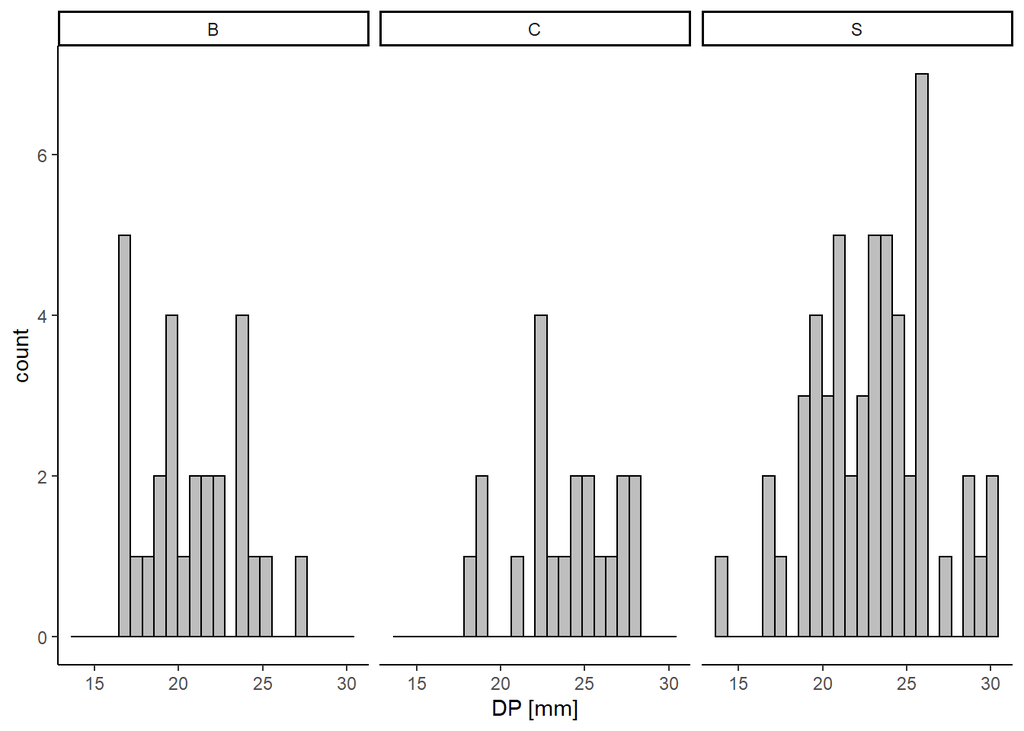

```r
hist_data <- ggplot(data_test, aes(x = DP)) +
  geom_histogram(binwidth=0.7, colour="black", fill="grey") +
  facet_wrap(~Kolor, scales="fixed")+ theme_classic() + xlab("DP [mm]")
plot(hist_data)
```

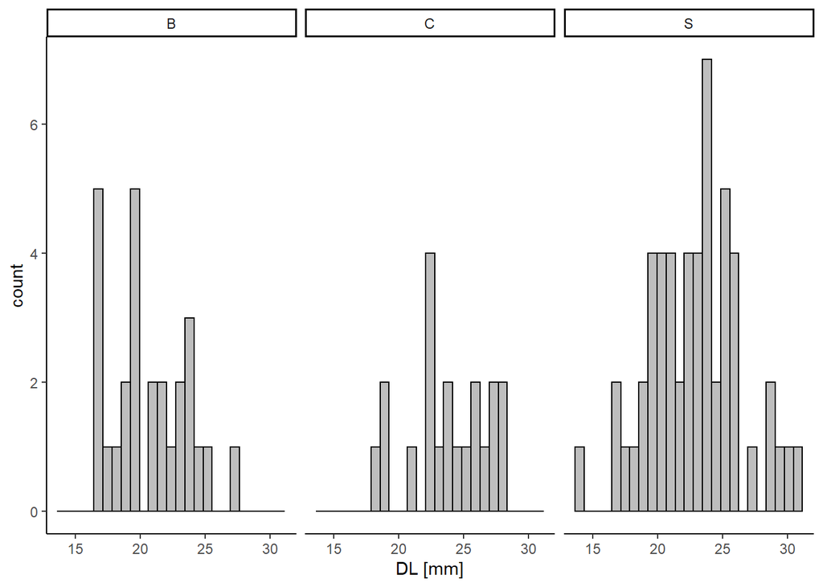

```r
hist_data2 <- ggplot(data_test, aes(x = DL)) +
  geom_histogram(binwidth=0.7, colour="black", fill="grey") +
  facet_wrap(~Kolor, scales="fixed")+ theme_classic() + xlab("DL [mm]")
plot(hist_data2)
```

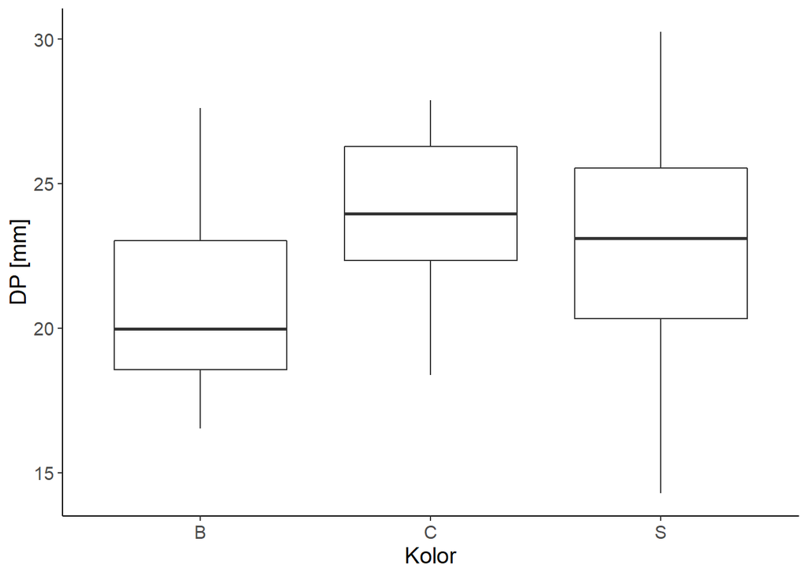

```r
data_plot <- ggplot(data = data_test, mapping = aes(x = Kolor, y = DP)) +
  geom_boxplot(alpha = 0.3) + theme_classic() + theme(text = element_text(size = 14)) +
  labs(x = "Kolor", y = "DP [mm]")
plot(data_plot)
```

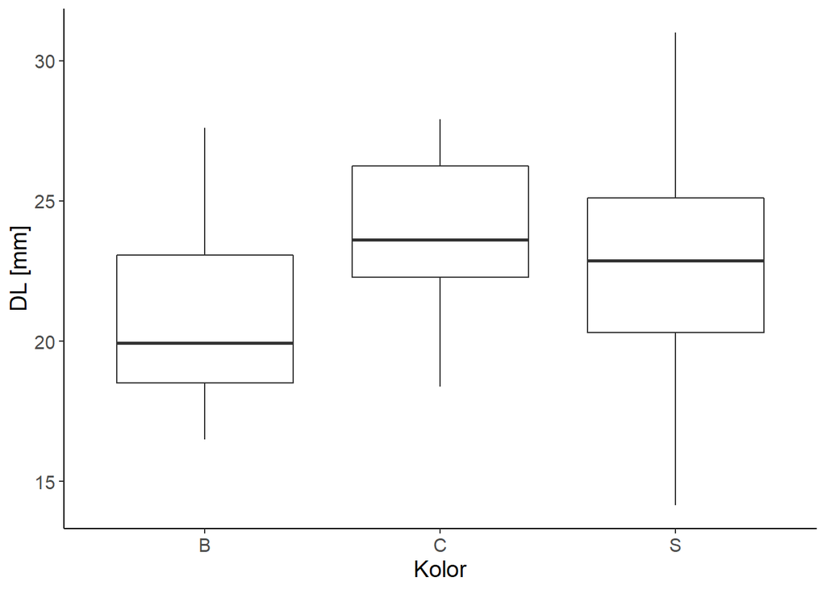

```r
data_plot2 <- ggplot(data = data_test, mapping = aes(x = Kolor, y = DL)) +
  geom_boxplot(alpha = 0.3) + theme_classic() + theme(text = element_text(size = 14)) +
  labs(x = "Kolor", y = "DL [mm]")
plot(data_plot2)
```

Te wyniki nie odnoszą się bezpośrednio do pytania postawionego w zadaniu, lepsze będą wykresy:

```r
df <- data.frame(group = rep(c("DP", "DL"), D = c(data_test$DP,data_test$DL)))
df
```

```
##   group
## 1    DP
## 2    DL
```

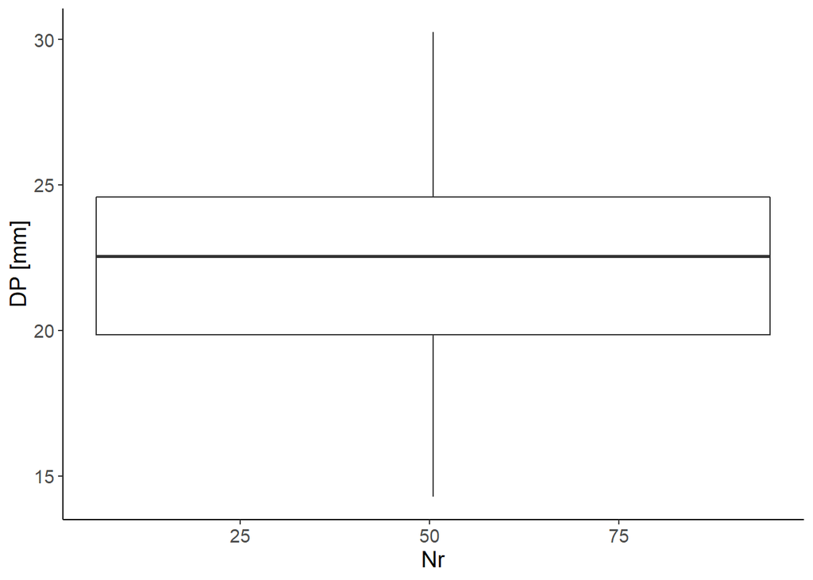

```r
df <- data.frame( group = rep(c("DP", "DL"), each = 100),
    length = c(data_test$DP,  data_test$DL))

data_plot3 <- ggplot(data = data_test, mapping = aes(x = Nr, y = DP)) +
  geom_boxplot(alpha = 0.3) + theme_classic() + theme(text = element_text(size = 14)) +
  labs(x = "Nr", y = "DP [mm]")
plot(data_plot3)
```

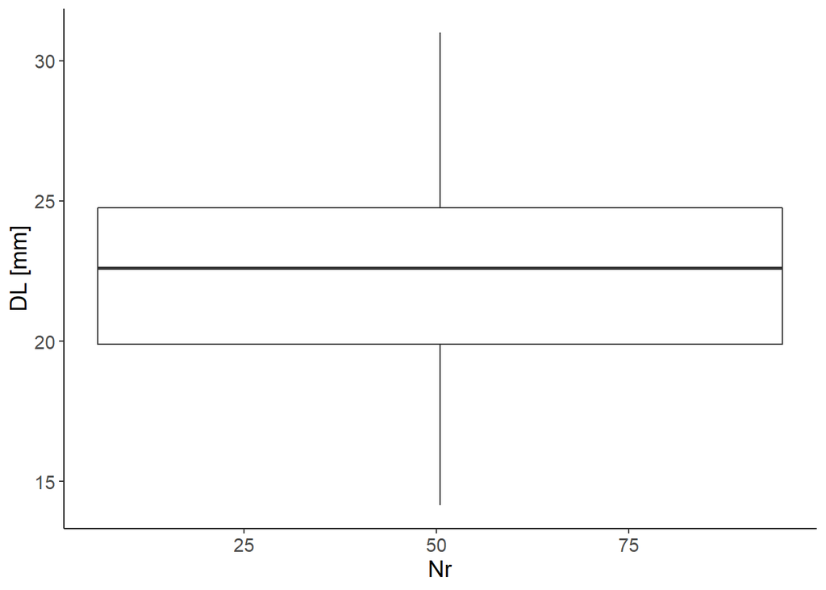

```r
data_plot4 <- ggplot(data = data_test, mapping = aes(x = Nr, y = DL)) +
  geom_boxplot(alpha = 0.3) + theme_classic() + theme(text = element_text(size = 14)) +
  labs(x = "Nr", y = "DL [mm]")
plot(data_plot4)
```

test:

```r
ts <- t.test(length ~ group, data = df, paired = T)
ts
```

```
##
##  Paired t-test
##
## data:  length by group
## t = -1.7854, df = 99, p-value = 0.07726
## alternative hypothesis: true difference in means is not equal to 0
## 95 percent confidence interval:
##  -0.085721969  0.004521969
## sample estimates:
## mean of the differences
##                 -0.0406
```

Wnioski:  
p-value > 0,05 należy przyjąc hiptoezę zerową, że kończyna lewa średnio nie różni się długością od prawej

## Zadanie 3

**Adekwatne statystyki opisowe i wykresy diagnostyczne niezbędne do podjęcia ostatecznej decyzji w wyborze metod testowania hipotezy:** Wykonane wyżej przed statystykami odpowiednimi dla poprzedniego testu.

**Testy “z wyboru”:**

Test ANOVA.

**Założenia teoretycznie dotyczące rozkładu wymagane dla wybranego testu:**

Rozkład zbliżony do normalnego. Homogeniczność wariancji między grupami. Z uwagi na czas przyjmujemy, że założenia są spełnione.

**Test ANOVA:**

```r
data_test$mean <- ((data_test$DP+data_test$DL)/2)
summary(ANOVA_data <- aov(mean~ Kolor, data_test))
```

```
##             Df Sum Sq Mean Sq F value  Pr(>F)
## Kolor        2  132.1   66.04   6.237 0.00283 **
## Residuals   97 1027.1   10.59
## ---
## Signif. codes:  0 '***' 0.001 '**' 0.01 '*' 0.05 '.' 0.1 ' ' 1
```

**Rozkład reszt oraz wykresy obrazujące wyniki:**

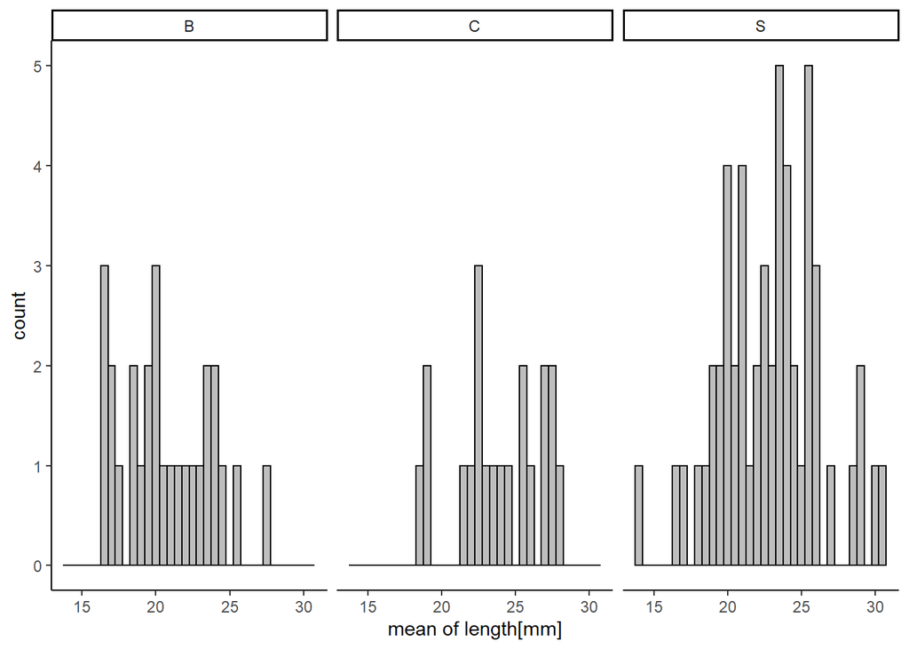

```r
hist_dataa <- ggplot(data_test, aes(x = mean)) +
  geom_histogram(binwidth=0.5, colour="black", fill="grey") +
  facet_wrap(~Kolor, scales="fixed")+ theme_classic() + xlab("mean of length[mm]")
plot(hist_dataa)
```

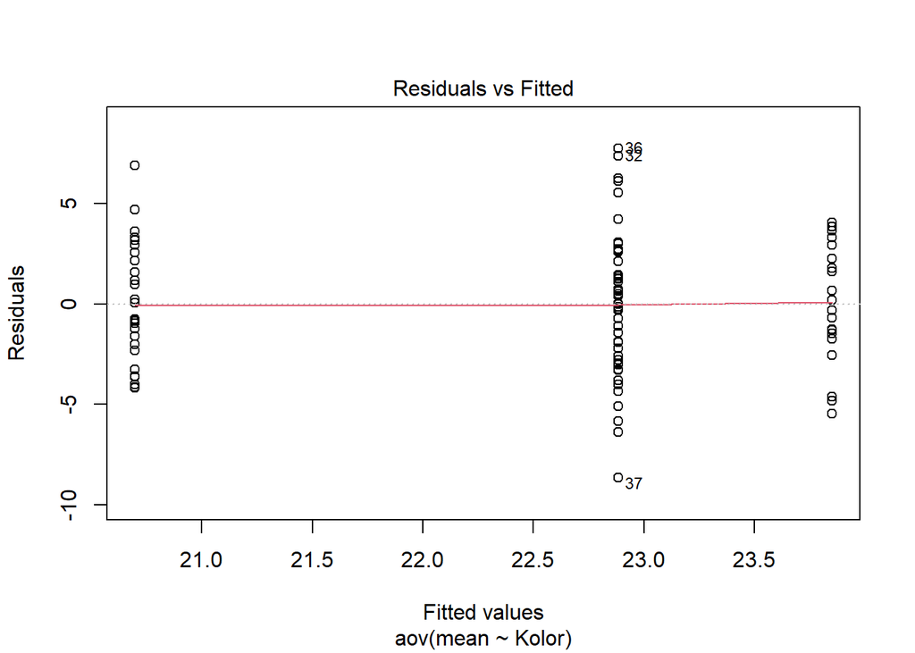

```r
plot(ANOVA_data,1)
```

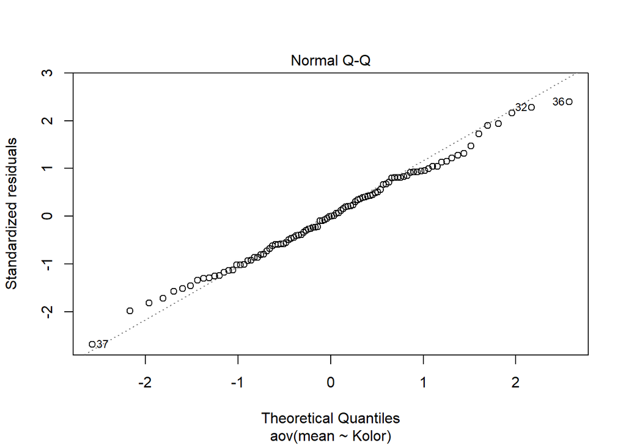

```r
plot(ANOVA_data,2)
```

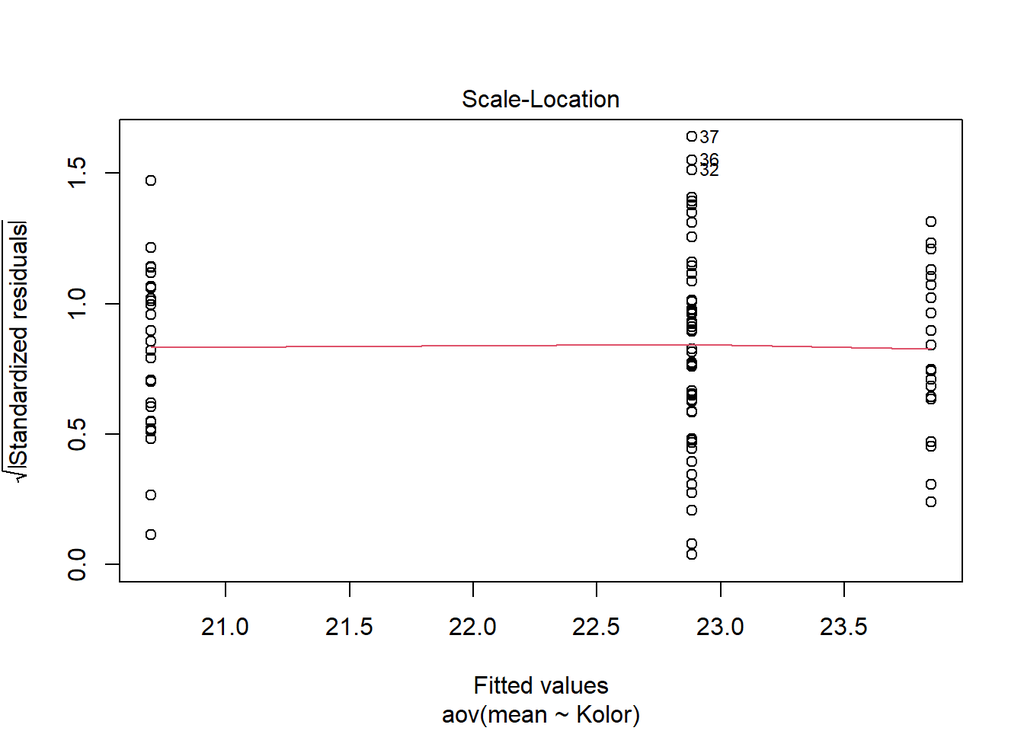

```r
plot(ANOVA_data,3)
```

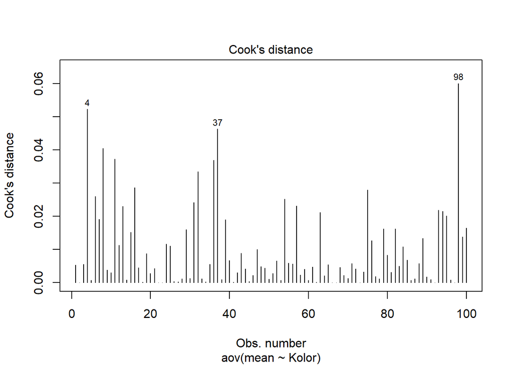

```r
plot(ANOVA_data,4)
```

Wnioski z wykresów:  
Rozkład jest bardzo zbliżony do normalnego, wartości wariancji są zbliżone do siebie, istniejące outlayery mają znikomy wpływ na wynik testu.